# Отчет по лабораторной работе №11

Настройка удалённого доступа к серверу с помощью SSH

Виноградова М.А

Российский университет дружбы народов, Москва, Россия

10 ноября 2026

# Информация

## Докладчик

- Виноградова Мария Андреевна
- студентка НПИбд-02-24
- номер студ. билета 1132240691
- Российский университет дружбы народов
- 1132240691@rudn.ru
- https://github.com/mavinogradova/study_2026-2027

# Цель работы

Приобретение практических навыков по настройке удалённого доступа к серверу с помощью SSH.

# Задание

1. Настройте запрет удалённого доступа на сервер по SSH для пользователя root (см. раздел 11.4.1).
2. Настройте разрешение удалённого доступа к серверу по SSH только для пользователей группы vagrant и вашего пользователя (см. раздел 11.4.2).
3. Настройте удалённый доступ к серверу по SSH через порт 2022 (см. раздел 11.4.3).
4. Настройте удалённый доступ к серверу по SSH по ключу (см. раздел 11.4.4).
5. Организуйте SSH-туннель с клиента на сервер, перенаправив локальное соединение с TCP-порта 80 на порт 8080 (см. раздел 11.4.5).
6. Используя удалённое SSH-соединение, выполните с клиента несколько команд на сервере (см. раздел 11.4.6).
7. Используя удалённое SSH-соединение, запустите с клиента графическое приложение на сервере (см. раздел 11.4.7).
8. Напишите скрипт для Vagrant, фиксирующий действия по настройке SSH-сервера во внутреннем окружении виртуальной машины server. Соответствующим образом внесите изменения в Vagrantfile (см. раздел 11.4.8).

# Выполнение лабораторной работы

## Запрет доступа для root. Задание пароля

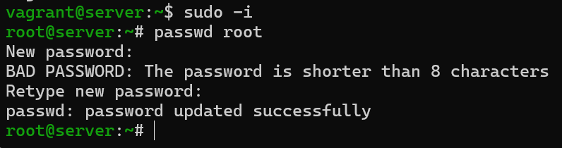

Задание пароля для пользователя root

## Запрет доступа для root. Мониторинг

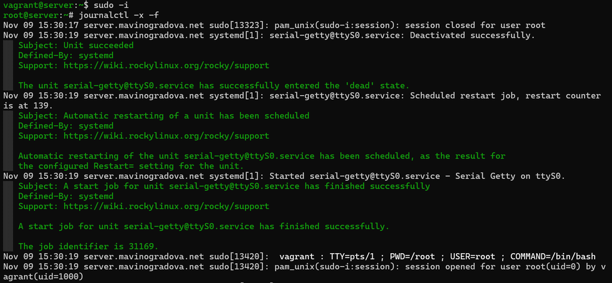

Мониторинг системных событий на сервере

## Запрет доступа для root. Вход до изменений

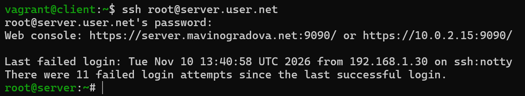

Успешный вход под root до изменения конфигурации

## Запрет доступа для root. Настройка конфига

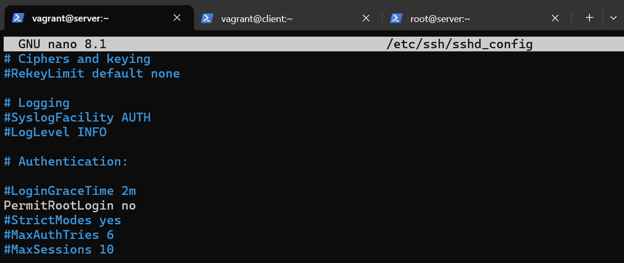

Настройка запрета входа для root

## Запрет доступа для root. Перезапуск

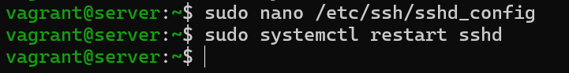

Перезапуск службы sshd

## Запрет доступа для root. Отказ

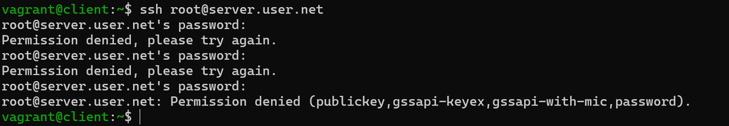

Отказ в доступе для root после изменения конфигурации

## Ограничение пользователей. Вход до ограничений

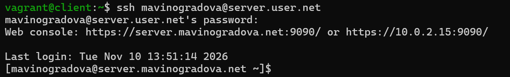

Успешный вход пользователя до применения ограничений

## Ограничение пользователей. AllowUsers vagrant

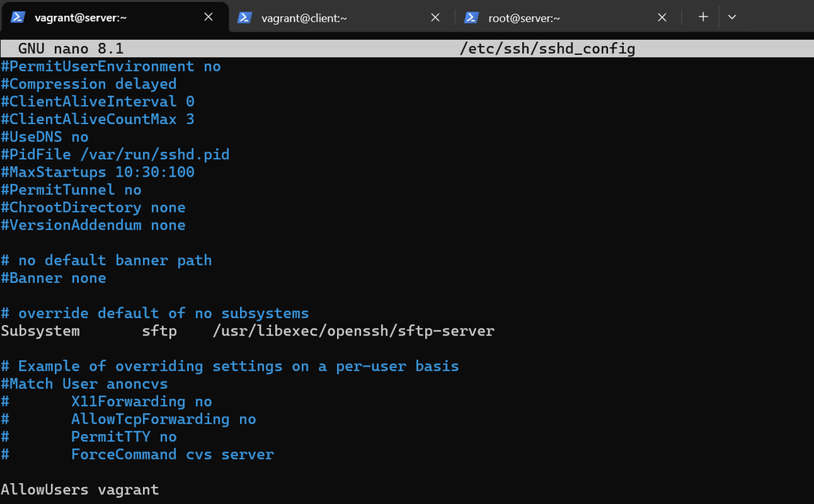

Добавление директивы AllowUsers

## Ограничение пользователей. Перезапуск 1

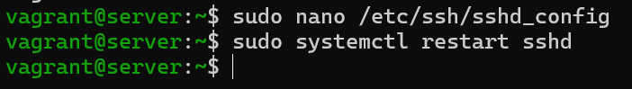

Перезапуск sshd после добавления AllowUsers

## Ограничение пользователей. Отказ

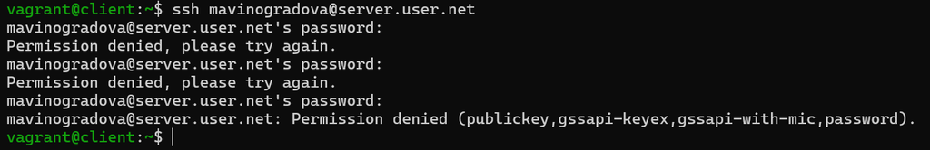

Отказ в доступе после добавления AllowUsers

## Ограничение пользователей. AllowUsers + mavinogradova

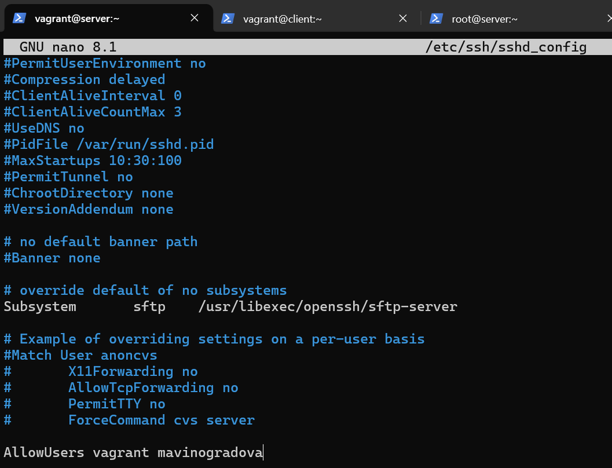

Добавление пользователя в AllowUsers

## Ограничение пользователей. Перезапуск 2

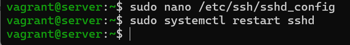

Перезапуск sshd после изменения AllowUsers

## Ограничение пользователей. Успех

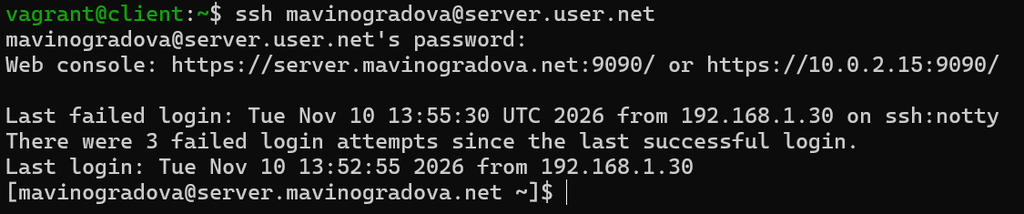

Успешный вход после добавления в AllowUsers

## Порты. Добавление порта 2022

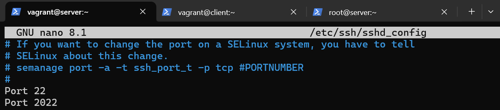

Добавление порта 2022

## Порты. Ошибка SELinux

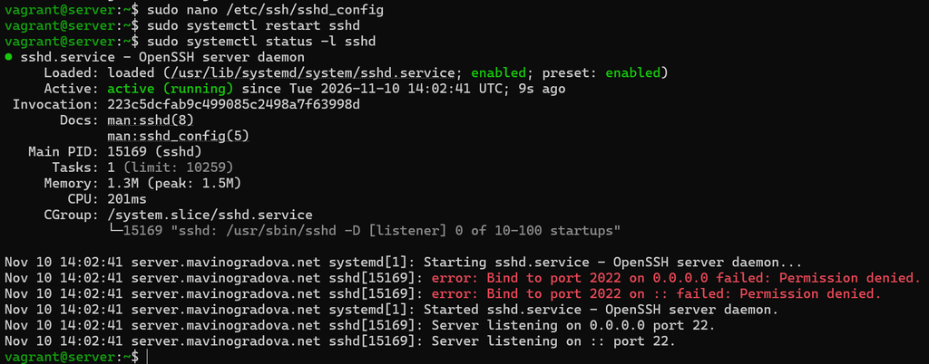

Ошибка запуска на порту 2022

## Порты. Успешный запуск

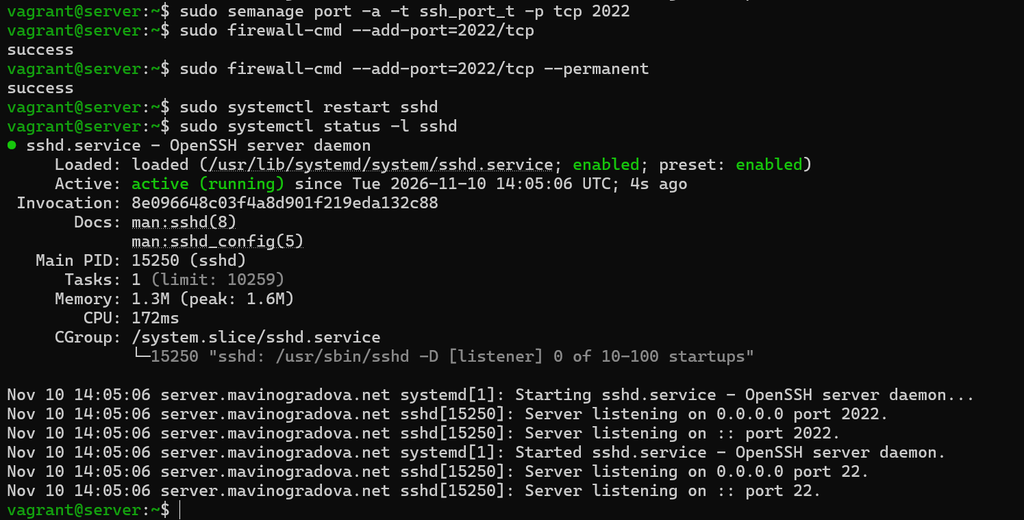

Успешный запуск sshd на двух портах

## Порты. Проверка входа

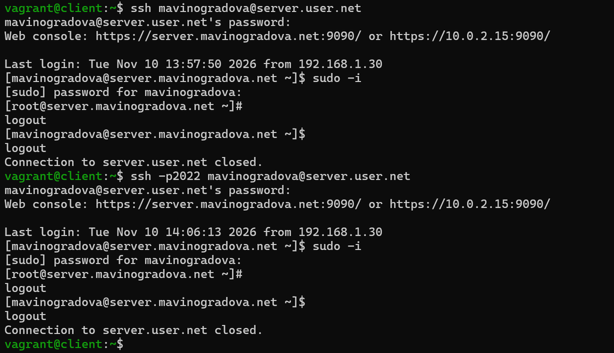

Проверка доступа через порты 22 и 2022

## Ключи. Включение PubkeyAuthentication

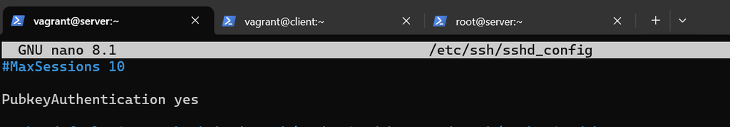

Включение аутентификации по ключу

## Ключи. Перезапуск

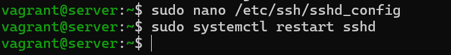

Перезапуск sshd

## Ключи. Генерация

[figure not shown]

Генерация SSH-ключа

## Ключи. Копирование на сервер

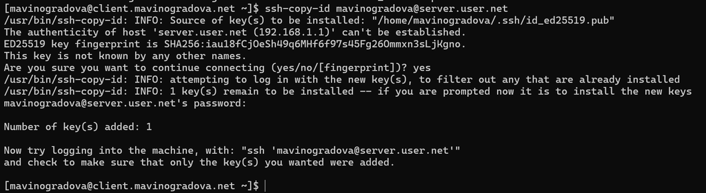

Копирование ключа на сервер

## Ключи. Вход без пароля

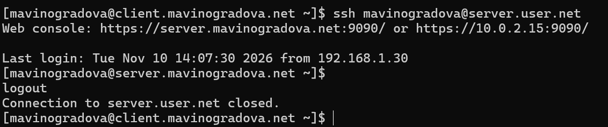

Вход без пароля по ключу

## Туннель. Службы до

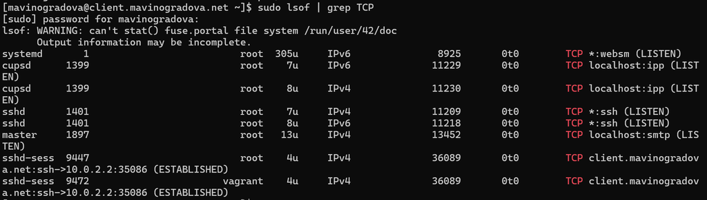

Список TCP-служб до создания туннеля

## Туннель. Создание и службы после

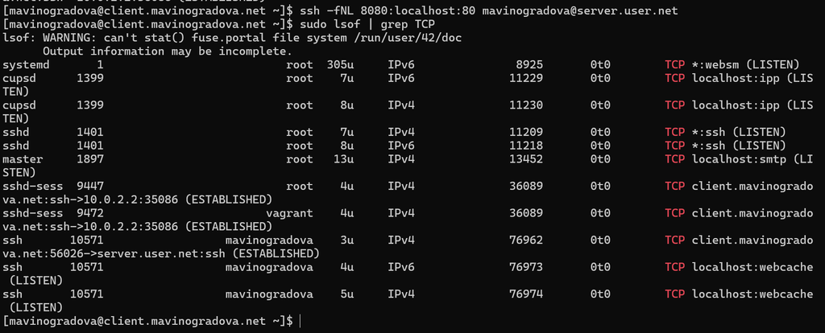

Проверка TCP-служб после создания туннеля

## Туннель. Проверка работы

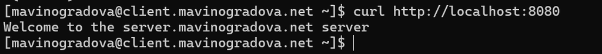

Проверка работы туннеля

## Консольные приложения

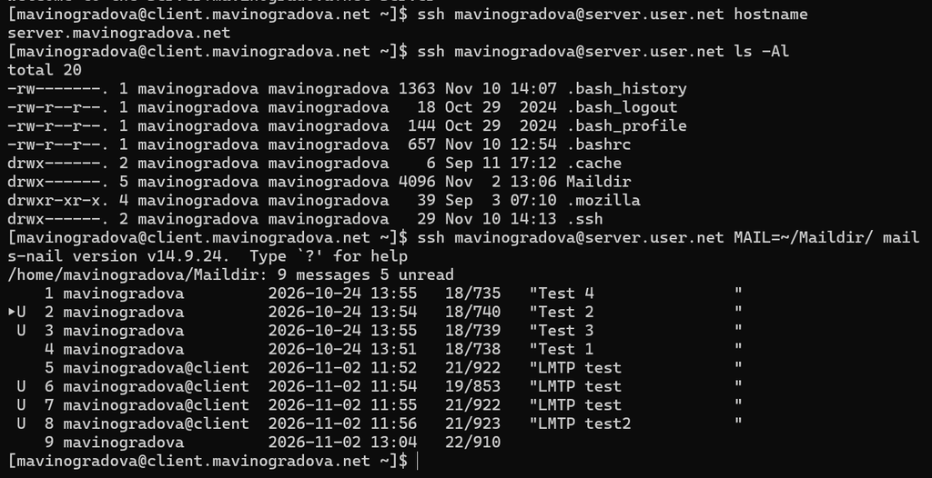

Выполнение консольных команд через SSH

## Графические приложения. Настройка

[figure not shown]

Разрешение X11Forwarding

## Графические приложения. Перезапуск

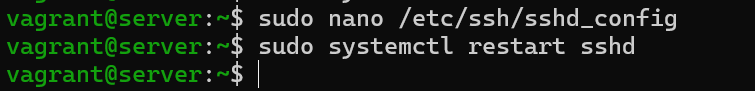

Перезапуск sshd